# Individual Project

Neil Francis N. Navarro

2022-11-27

#Packages that will be needed

```r
library("twitteR")
library(dplyr)
library(tidyr)
```

```r
library("plotly")
library(ggplot2)
library(RColorBrewer)
library(tidytext)
library(rtweet)
library(tm)
library(slam)
library(wordcloud)
library(wordcloud2)
library(corpus)
```

##1. Extract from twitter using your developer’s credentials. Choose any keyword you want.

#Set-up credentials

```r
CONSUMER_SECRET <- "vszUMNiOPeq1GRJmY1nuBHjFtZ6LsN0aO6CxYcnc2py27dNitF"
CONSUMER_KEY <- "aOMew0VvV9MbbQ5vEGCD1DQdg"
ACCESS_SECRET <- "1WlX6wXKyVV5My2GtoRltT9OtZzAyods5tSUIXWbUsZLp"
ACCESS_TOKEN <- "1595950464826507264-doMSI0oqDJdqmxTX4aO7ohaTSCAKuM"
```

#connect to twitter app

```r
setup_twitter_oauth(consumer_key = CONSUMER_KEY,
                    consumer_secret = CONSUMER_SECRET,
                    access_token = ACCESS_TOKEN,
                    access_secret = ACCESS_SECRET)
```

```
## [1] "Using direct authentication"
```

##2. Get 10000 observations “excluding retweets.

#Getting a data #it would take few minutes to load which depend the number of data you need #but when you already save this data as a file you can skip this part.

```r
trendTweets <- searchTwitter("#tiktok -filter:retweets",
                             n = 10000,
                             lang = "en",
                             since = "2022-11-20",
                             until = "2022-11-24",
                             retryOnRateLimit=120)
trendTweets
```

[output not shown]

[output cut: 29944 more lines]

[output not shown]

```r
save(trendTweets, file = "trendSteets.Rdata")
```

```r
head(trendTweets)
```

```
## [[1]]
## [1] "soydaddyyy: Just got back to posting on #TikTok and tiktok announces new algorithm changes 💀"
##
## [[2]]
## [1] "CircleOfSylvan: Hey friends, so no jury duty today. Which means I'm going to do my marathon stream tonight as tomorrow is a holiday… https://t.co/sqfEj0t7Io"
##
## [[3]]
## [1] "MAGABOSSDiCK: Check out logically_ill4's video! #TikTok https://t.co/wYHTwoyZDK"
##
## [[4]]
## [1] "Justice121264: Check out Trump Vlogs's video! #TikTok https://t.co/X8cfdIoimX"
##
## [[5]]
## [1] "JohnOrtizKehoe: Follow me on #TikTok \n#DebunkedEvidence #MichiganProsecutor #VoiceOfAPrisoner #LifeOfAPrisoner #fightwithme… https://t.co/r91idAcfL7"
##
## [[6]]
## [1] "ShyamKu49663830: Hello Sir By Mistake My Video Delete Please 😓 Recover My Video\n(Video Tittle)Picsart: 3 Top Photo Editing || Picsar… https://t.co/0GH0yKDt08"
```

#Converting data into dataframe

```r
trendTweetsDF <- twListToDF(trendTweets)
class(trendTweetsDF)
```

```
## [1] "data.frame"
```

```r
names(trendTweetsDF)
```

```
##  [1] "text"          "favorited"     "favoriteCount" "replyToSN"
##  [5] "created"       "truncated"     "replyToSID"    "id"
##  [9] "replyToUID"    "statusSource"  "screenName"    "retweetCount"
## [13] "isRetweet"     "retweeted"     "longitude"     "latitude"
```

```r
View(trendTweetsDF)
head(trendTweetsDF)[1:5]
```

```
##                                                                                                                                            text
## 1                                                              Just got back to posting on #TikTok and tiktok announces new algorithm changes 💀
## 2  Hey friends, so no jury duty today. Which means I'm going to do my marathon stream tonight as tomorrow is a holiday… https://t.co/sqfEj0t7Io
## 3                                                                             Check out logically_ill4's video! #TikTok https://t.co/wYHTwoyZDK
## 4                                                                                Check out Trump Vlogs's video! #TikTok https://t.co/X8cfdIoimX
## 5         Follow me on #TikTok \n#DebunkedEvidence #MichiganProsecutor #VoiceOfAPrisoner #LifeOfAPrisoner #fightwithme… https://t.co/r91idAcfL7
## 6 Hello Sir By Mistake My Video Delete Please 😓 Recover My Video\n(Video Tittle)Picsart: 3 Top Photo Editing || Picsar… https://t.co/0GH0yKDt08
##   favorited favoriteCount replyToSN             created
## 1     FALSE             2      <NA> 2022-11-23 23:59:58
## 2     FALSE             1      <NA> 2022-11-23 23:59:53
## 3     FALSE             0      <NA> 2022-11-23 23:59:49
## 4     FALSE             0      <NA> 2022-11-23 23:59:49
## 5     FALSE             4      <NA> 2022-11-23 23:59:21
## 6     FALSE             1      <NA> 2022-11-23 23:59:10
```

```r
head(trendTweetsDF$text)[1:5]
```

```
## [1] "Just got back to posting on #TikTok and tiktok announces new algorithm changes 💀"
## [2] "Hey friends, so no jury duty today. Which means I'm going to do my marathon stream tonight as tomorrow is a holiday… https://t.co/sqfEj0t7Io"
## [3] "Check out logically_ill4's video! #TikTok https://t.co/wYHTwoyZDK"
## [4] "Check out Trump Vlogs's video! #TikTok https://t.co/X8cfdIoimX"
## [5] "Follow me on #TikTok \n#DebunkedEvidence #MichiganProsecutor #VoiceOfAPrisoner #LifeOfAPrisoner #fightwithme… https://t.co/r91idAcfL7"
```

#Saving the data into a file

```r
save(trendTweetsDF,file = "trendingTweetsDF.Rdata")
load(file = "trendingTweetsDF.Rdata")
```

#Checking for missing values in a data frame

```r
sapply(trendTweetsDF, function(x) sum(is.na(x)))
```

```
##          text     favorited favoriteCount     replyToSN       created
##             0             0             0          9791             0
##     truncated    replyToSID            id    replyToUID  statusSource
##             0          9911             0          9791             0
##    screenName  retweetCount     isRetweet     retweeted     longitude
##             0             0             0             0         10000
##      latitude
##         10000
```

#Subsetting using the dplyr()package

```r
tweetsDF <- trendTweetsDF %>%
  select(screenName,text,created,statusSource)
```

#saving file as Rdata

```r
save(tweetsDF, file = "tweetsDF.Rdata")
load(file = "tweetsDf.Rdata")
```

##3. Plot the time series from the date created. with legends.

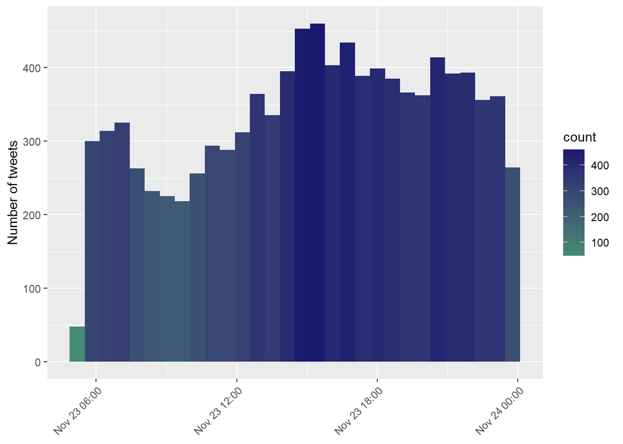

```r
ggplot(data = tweetsDF, aes(x = created), fill = tweetsDF) +
  geom_histogram(aes(fill = ..count..)) +
  theme(legend.position="right",
        axis.title.x = element_blank(),
        axis.text.x = element_text(angle = 45, hjust = 1)) +
  xlab("Time") + ylab("Number of tweets") +
  scale_fill_gradient(low = "aquamarine4", high = "midnightblue")
```

##4. Plot a graph (any graph you want) based on the type of device - found in Source #- that the user use. Include the legends.

```r
encodeSource <- function(x) {
  if(grepl(">Twitter for iPhone</a>", x)){
    "iphone"
  }else if(grepl(">Twitter for iPad</a>", x)){
    "ipad"
  }else if(grepl(">Twitter for Android</a>", x)){
    "android"
  } else if(grepl(">Twitter Web Client</a>", x)){
    "Web"
  } else if(grepl(">Twitter for Windows Phone</a>", x)){
    "windows phone"
  }else if(grepl(">dlvr.it</a>", x)){
    "dlvr.it"
  }else if(grepl(">IFTTT</a>", x)){
    "ifttt"
  }else if(grepl(">Facebook</a>", x)){
    "facebook"
  }else {
    "others"
  }
}


tweetsDF$tweetSource = sapply(tweetsDF$statusSource,
                              encodeSource)

tweet_appSource <- tweetsDF %>%
  select(tweetSource) %>%
  group_by(tweetSource) %>%
  summarize(count=n()) %>%
  arrange(desc(count))

Source_subset <- subset(tweet_appSource,count >10)
```

```r
dataDF <- data.frame(
  category = tweet_appSource$tweetSource,
  count = tweet_appSource$count
)

dataDF$fraction = dataDF$count / sum(dataDF$count)
dataDF$percentage = dataDF$count / sum(dataDF$count) * 100
dataDF$ymax = cumsum(dataDF$fraction)
dataDF$ymin = c(0, head(dataDF$ymax, n=-1))
dataDF$roundP = round(dataDF$percentage, digits = 2)
```

#plotting using geom_bar() - bar graph

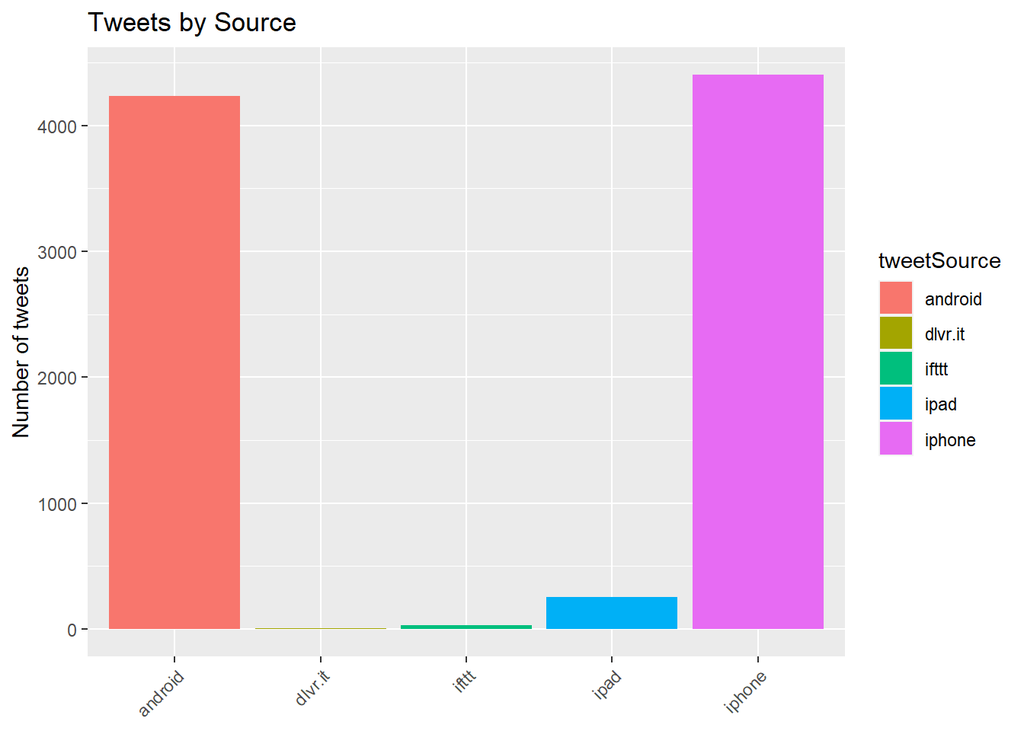

```r
ggplot(tweetsDF[tweetsDF$tweetSource != 'others',], aes(tweetSource, fill = tweetSource)) +
  geom_bar() +
  theme(legend.position="right",
        axis.title.x = element_blank(),
        axis.text.x = element_text(angle = 45, hjust = 1)) +
  ylab("Number of tweets") +
  ggtitle("Tweets by Source")
```

##5. Create a wordcloud from the screenName

#Using wordcloud() package but using a shape pentagon

```r
tweet_appScreen <- tweetsDF %>%
  select(screenName) %>%
  group_by(screenName) %>%
  summarize(count=n()) %>%
  arrange(desc(count))
```

#convert to Corpus

```r
namesCorpus <- Corpus(VectorSource(tweetsDF$screenName))
```

#Running the code using the wordcloud()

```r
wordcloud2(data=tweet_appScreen,
           size=0.8,
           color='random-dark',
           shape = 'pentagon')
```

[interactive chart not shown]